# Student_Analysis

Student Performance Analysis

This project explores academic performance patterns among students and identifies factors influencing exam outcomes using exploratory data analysis and visualization techniques.

```python
import pandas as pd
import numpy as np
import matplotlib.pyplot as plt
import seaborn as sns

# Load dataset
df = pd.read_csv("../data/StudentsPerformance.csv")

# Basic checks
print(df.info())
print(df.describe())
print(df.isnull().sum())
print("Duplicates:", df.duplicated().sum())

# Remove duplicates if any
df = df.drop_duplicates()

# Create total score column
df["total_score"] = df["math score"] + df["reading score"] + df["writing score"]

df.head()
```

```
<class 'pandas.DataFrame'>
RangeIndex: 1000 entries, 0 to 999
Data columns (total 8 columns):
 #   Column                       Non-Null Count  Dtype
---  ------                       --------------  -----
 0   gender                       1000 non-null   str
 1   race/ethnicity               1000 non-null   str
 2   parental level of education  1000 non-null   str
 3   lunch                        1000 non-null   str
 4   test preparation course      1000 non-null   str
 5   math score                   1000 non-null   int64
 6   reading score                1000 non-null   int64
 7   writing score                1000 non-null   int64
dtypes: int64(3), str(5)
memory usage: 62.6 KB
None
       math score  reading score  writing score
count  1000.00000    1000.000000    1000.000000
mean     66.08900      69.169000      68.054000
std      15.16308      14.600192      15.195657
min       0.00000      17.000000      10.000000
25%      57.00000      59.000000      57.750000
50%      66.00000      70.000000      69.000000
75%      77.00000      79.000000      79.000000
max     100.00000     100.000000     100.000000
gender                         0
race/ethnicity                 0
parental level of education    0
lunch                          0
test preparation course        0
math score                     0
reading score                  0
writing score                  0
dtype: int64
Duplicates: 0
```

|  | gender | race/ethnicity | parental level of education | lunch | test preparation course | math score | reading score | writing score | total_score |
| --- | --- | --- | --- | --- | --- | --- | --- | --- | --- |
| 0 | female | group B | bachelor's degree | standard | none | 72 | 72 | 74 | 218 |
| 1 | female | group C | some college | standard | completed | 69 | 90 | 88 | 247 |
| 2 | female | group B | master's degree | standard | none | 90 | 95 | 93 | 278 |
| 3 | male | group A | associate's degree | free/reduced | none | 47 | 57 | 44 | 148 |
| 4 | male | group C | some college | standard | none | 76 | 78 | 75 | 229 |

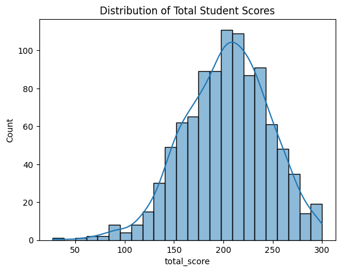

```python
sns.histplot(df["total_score"], kde=True)
plt.title("Distribution of Total Student Scores")
plt.show()
```

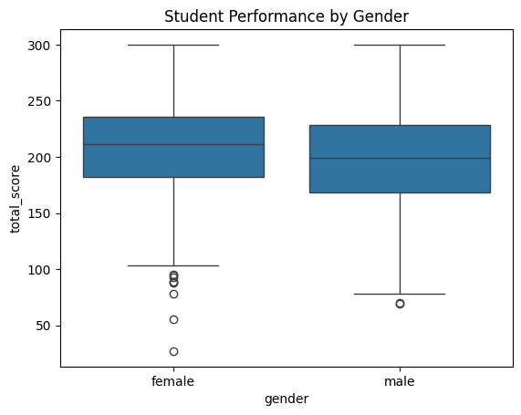

```python
sns.boxplot(x="gender", y="total_score", data=df)
plt.title("Student Performance by Gender")
plt.show()
```

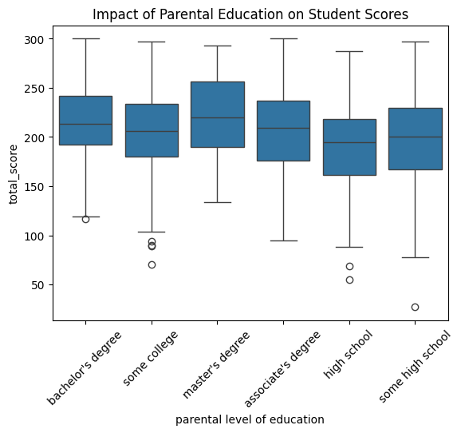

```python
sns.boxplot(x="parental level of education", y="total_score", data=df)
plt.xticks(rotation=45)
plt.title("Impact of Parental Education on Student Scores")
plt.show()
```

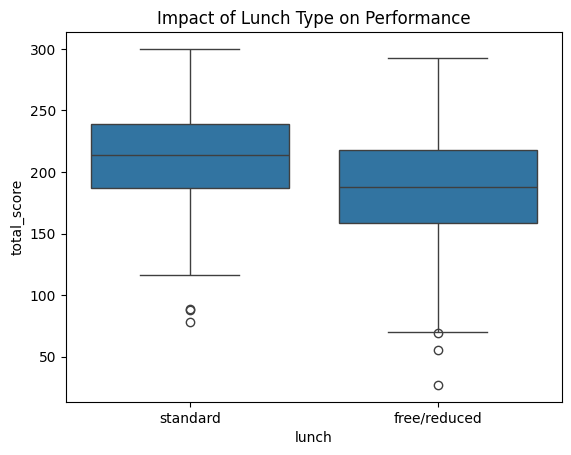

```python
sns.boxplot(x="lunch", y="total_score", data=df)
plt.title("Impact of Lunch Type on Performance")
plt.show()
```

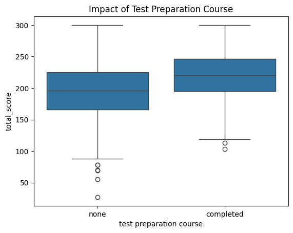

```python
sns.boxplot(x="test preparation course", y="total_score", data=df)
plt.title("Impact of Test Preparation Course")
plt.show()
```

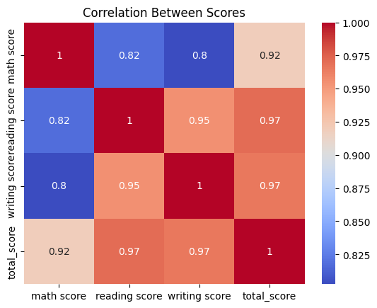

```python
sns.heatmap(df[["math score","reading score","writing score","total_score"]].corr(), annot=True, cmap="coolwarm")
plt.title("Correlation Between Scores")
plt.show()
```

Key Insights from Student Performance Analysis

Parental education has noticeable influence Students whose parents had higher education levels showed better academic outcomes on average.

Lunch type correlates with performance Students receiving standard lunch performed better than those on free/reduced lunch, indicating possible socioeconomic effects.

Reading and writing scores are strongly correlated Students who do well in reading usually also perform well in writing.

Gender differences are small While there are slight variations, overall performance differences between genders are not drastic.

Conclusion

This analysis explored factors influencing student academic performance using exam score data.

The study revealed that preparation courses and parental education levels play a key role in determining outcomes. Socioeconomic indicators such as lunch type also show meaningful influence. Strong correlations between reading and writing scores suggest that literacy skills are interconnected.

These findings suggest that schools can improve student outcomes by encouraging preparation programs, supporting literacy development, and addressing socioeconomic barriers.